# Enrichment analysis for astrocytes

Alexis Felipe Rojas Cruz

The purpose of Venn diagrams is to identify shared DEGs with a variety of contrasts and related treatments. For this study, we found that Tibolone has no effect on astrocytes treated with Palmitic Acid. Based on the Venn diagram analyses, it was found the Palmitic Acid induced DEGs listed below to perform the enrichment analysis

| No. | Treatment | Contrast | Up DEGs | Down DEGs |
| --- | --- | --- | --- | --- |
| 1 | Palmitic Acid | AstroTIBPA vs AstroVH, AstroPA vs AstroVH | 366 | 373 |

## Loading data

We will employ the intercepts of the shared DEGs across contrasts for the treatment of PA involving up- and down-regulated genes. In addition, filtered genes obtained by differential expression analysis will be included to perform overrepresentation

```r
PA_up <- read.csv("../Overlapping/overlap_DEGs/PA-DEG_up.csv", sep = ",", header = T)
PA_down <- read.csv("../Overlapping/overlap_DEGs/PA-DEG_down.csv", sep = ",", header = T)

univ <- read.csv("../Expression/Annotation/allgenesfilt.csv", sep = ",", header = T)
```

# Over-representation Analyses (ORA)

Over-representation (or enrichment) analysis is a statistical method that determines whether genes from pre-defined sets (ex: those belonging to a specific GO term or pathway) are present more than would be expected (over-represented) in a subset of your data

## Preparing data

```r
# Palmitic Acid
PAup_org <- clusterProfiler::bitr(PA_up$PAvsVH_symbol, fromType="SYMBOL", toType="ENTREZID", OrgDb="org.Hs.eg.db" ) %>%
  dplyr::select( ENTREZID ) %>%
  dplyr::rename( Entrez = ENTREZID ) %>%
  add_column( Treatment = "PA", Regulation = "Up" )

PAdown_org <- clusterProfiler::bitr(PA_down$PAvsVH_symbol, fromType="SYMBOL", toType="ENTREZID", OrgDb="org.Hs.eg.db" ) %>%
  dplyr::select( ENTREZID ) %>%
  dplyr::rename( Entrez = ENTREZID ) %>%
  add_column( Treatment = "PA", Regulation = "Down" )

mart <- useMart(biomart="ENSEMBL_MART_ENSEMBL", path="/biomart/martservice", dataset="hsapiens_gene_ensembl")
symbols <- getBM(values=univ$gene_id, filters= "ensembl_gene_id", attributes= c("ensembl_gene_id", "hgnc_symbol","entrezgene_id"), mart= mart)

# Universe
univ_enrich <- symbols %>%
  dplyr::rename( gene_id = ensembl_gene_id ) %>%
  dplyr::rename( Entrez = entrezgene_id ) %>%
  merge( univ, ., by="gene_id" ) %>%
  dplyr::select( Entrez ) %>%
  as.data.frame( . ) %>%
  unique( . )
```

To create a single dataset for our DEGs, we will merge the different data frames

```r
astro_enrich <- dplyr::bind_rows( PAup_org, PAdown_org )
head(astro_enrich)
```

|  | Entrez | Treatment | Regulation |
| --- | --- | --- | --- |
| 1 | 3949 | PA | Up |
| 2 | 467 | PA | Up |
| 3 | 4864 | PA | Up |
| 4 | 123 | PA | Up |
| 5 | 6319 | PA | Up |
| 6 | 4783 | PA | Up |

```r
NA
```

## GO Terms

`clusterProfiler` was developed for biological theme comparison, and it provides a function, `compareCluster`, to automatically calculate enriched functional categories of each gene clusters. This is an innovative analysis which enables us to compare DEGs by rormula interface *Entrez∼group or Entrez∼group+othergroup* and provides differences and similarities among the groups we are studying.

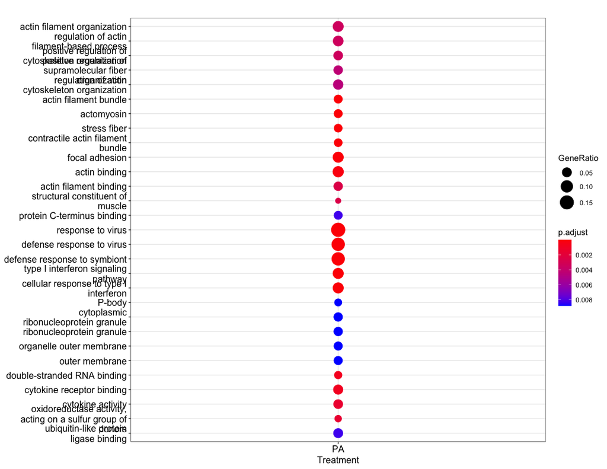

```r
compareGO = compareCluster(Entrez ~ Treatment+Regulation, data = astro_enrich,  fun ="enrichGO",
                           ont = "ALL", OrgDb = org.Hs.eg.db, pAdjustMethod = "BH", pvalueCutoff  = 0.01,
                           qvalueCutoff  = 0.05, readable = TRUE)


p1 <- dotplot(compareGO, x="Treatment",split = "ONTOLOGY", showCategory = 5) +
  aes(x=fct_relevel(Treatment, c('PA'))) + xlab(NULL) +
  facet_grid(vars(ONTOLOGY), vars(factor(Regulation, levels = c("Up", "Down"))),
  scale = "free", space = "free") +
  scale_color_gradientn(colours=c("#f7ca64", "#46bac2", "#371ea3"),
  guide=guide_colorbar(reverse=TRUE, order=1)) +
  force_panelsizes(cols = c(0.01, 0.01)) +
  guides(size = guide_legend(override.aes=list(shape=1))) +
  theme(panel.grid.major.y = element_line(linetype='dotted', color='#808080'),
  axis.text.y = element_text(size = 18), axis.text.x = element_text(size = 28),
  panel.grid.major.x = element_blank()) +
  theme(strip.text.x = element_text(size = 24), strip.text.y = element_text(size = 24),
  legend.title = element_text(size = 26, face = "bold"), legend.text = element_text(size = 22))
```

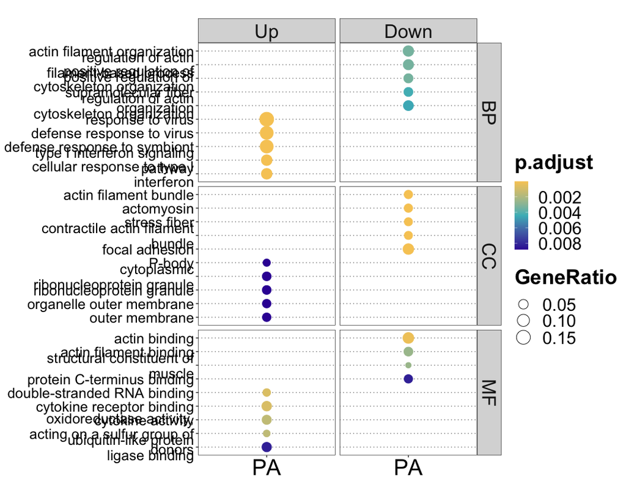

```r
p1
```

```r
ggsave("../Enrichment/enrich_plots/enrichGO.pdf", plot = p1, dpi = 600, width = 9, height = 19)
```

```r
GO_PA <- compareGO@compareClusterResult %>%
  filter( compareGO@compareClusterResult$Treatment == "PA" ) %>%
  arrange( desc(Regulation) )

write.csv(GO_PA, file="../Enrichment/enrich_GO/GO_PA.csv", quote = F, row.names = F)
```

## KEGG Pathway

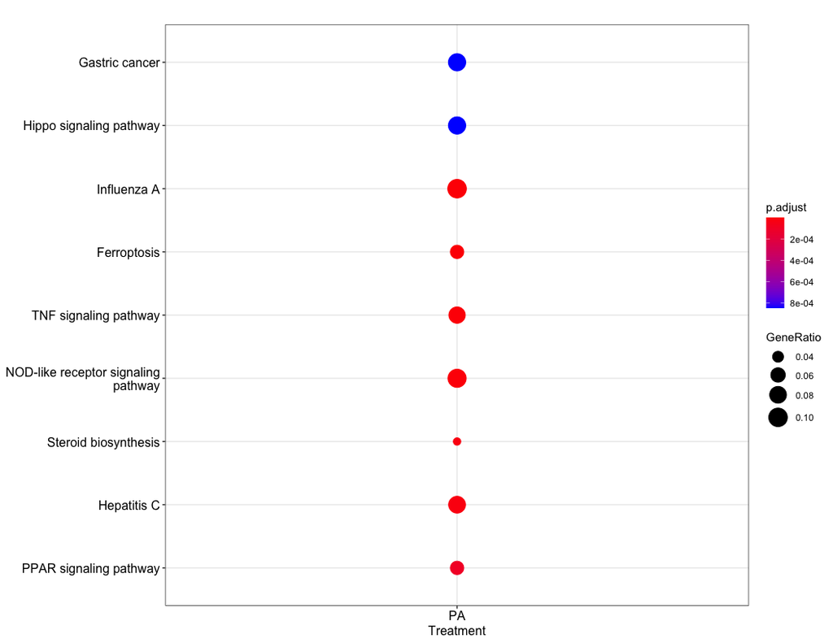

```r
compareKEGG = compareCluster(Entrez ~ Treatment+Regulation, data = astro_enrich, fun ="enrichKEGG",
                           organism = "hsa", pAdjustMethod = 'BH', pvalueCutoff = 0.01, qvalueCutoff  = 0.05)

p2 <- dotplot(compareKEGG, x="Treatment", showCategory = 7) +
  aes(x=fct_relevel(Treatment, c('PA'))) + xlab(NULL) +
  facet_grid(~factor(Regulation, levels = c("Up", "Down")), scale = "free", space = "free") +
  scale_color_gradientn(colours=c("#f7ca64", "#46bac2", "#371ea3"),
  guide=guide_colorbar(reverse=TRUE, order=1)) +
  force_panelsizes(cols = c(0.01, 0.01)) +
  guides(size = guide_legend(override.aes=list(shape=1))) +
  theme(panel.grid.major.y = element_line(linetype='dotted', color='#808080'),
  axis.text.y = element_text(size = 18), axis.text.x = element_text(size = 28),
  panel.grid.major.x = element_blank()) +
  theme(strip.text.x = element_text(size = 24), strip.text.y = element_text(size = 24),
  legend.title = element_text(size = 26, face = "bold"), legend.text = element_text(size = 22))
```

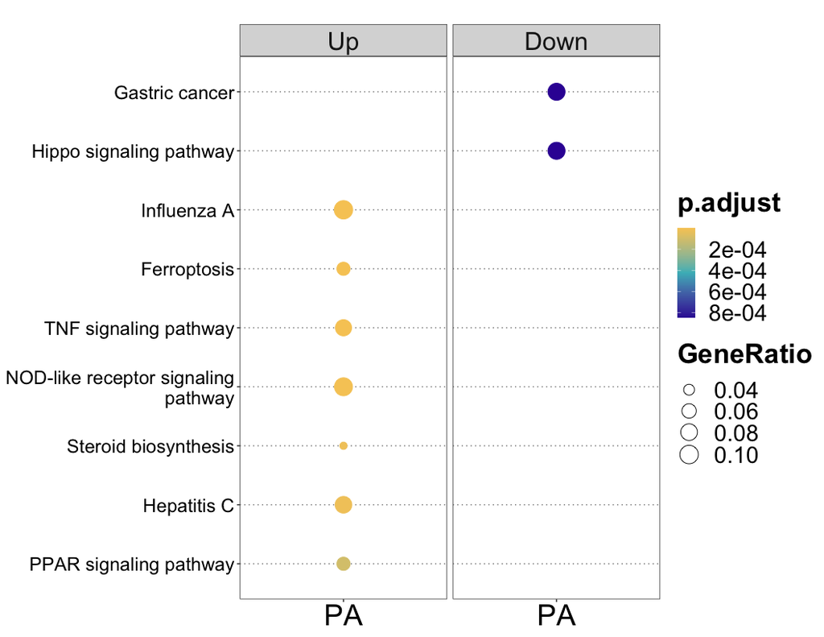

```r
p2
```

```r
ggsave("../Enrichment/enrich_plots/enrichKEGG.pdf", plot = p2, dpi = 600, width = 9, height = 6)
```

```r
KEGG_PA <- compareKEGG@compareClusterResult %>%
  filter( compareKEGG@compareClusterResult$Treatment == "PA" ) %>%
  arrange( desc(Regulation) )

write.csv(KEGG_PA, file="../Enrichment/enrich_KEGG/KEGG_PA.csv", quote = F, row.names = F)
```

## WikiPathways

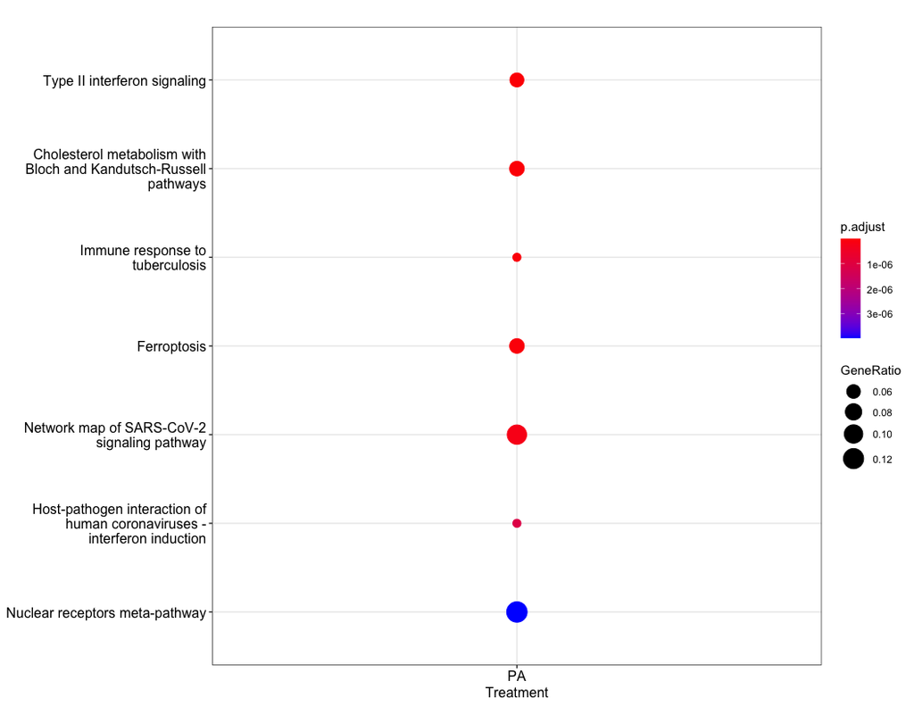

```r
compareWP <- compareCluster(Entrez ~ Treatment+Regulation, data = astro_enrich, fun ="enrichWP",
                           organism = "Homo sapiens", pAdjustMethod = 'BH', pvalueCutoff = 0.01, qvalueCutoff  = 0.05)

p3 <- dotplot(compareWP, x="Treatment", showCategory = 7) +
  aes(x=fct_relevel(Treatment, c('PA'))) + xlab(NULL) +
  facet_grid(~factor(Regulation, levels = c("Up", "Down")), scale = "free", space = "free") +
  scale_color_gradientn(colours=c("#f7ca64", "#46bac2", "#371ea3"),
  guide=guide_colorbar(reverse=TRUE, order=1)) +
  force_panelsizes(cols = c(0.01, 0.01)) +
  guides(size = guide_legend(override.aes=list(shape=1))) +
  theme(panel.grid.major.y = element_line(linetype='dotted', color='#808080'),
  axis.text.y = element_text(size = 18), axis.text.x = element_text(size = 28),
  panel.grid.major.x = element_blank()) +
  theme(strip.text.x = element_text(size = 24), strip.text.y = element_text(size = 24),
  legend.title = element_text(size = 26, face = "bold"), legend.text = element_text(size = 22))
```

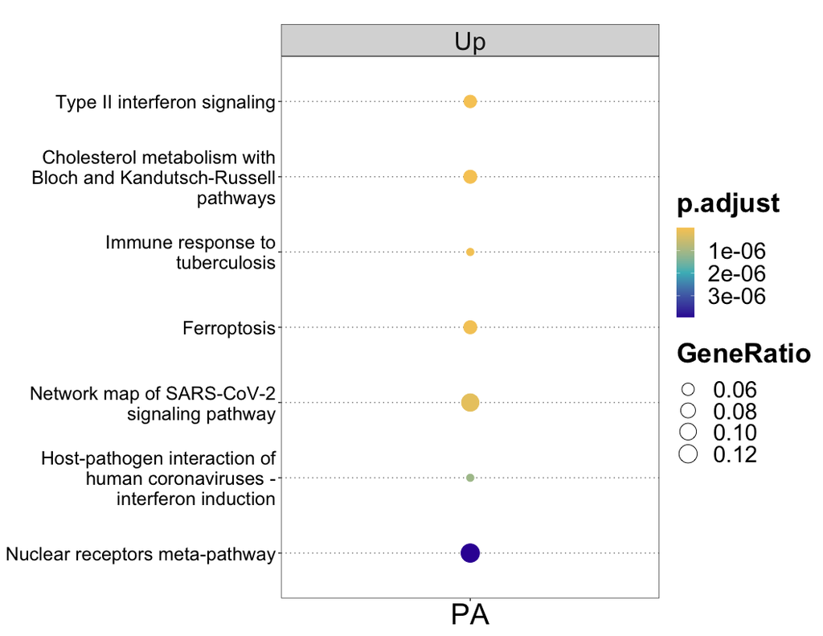

```r
p3
```

```r
ggsave("../Enrichment/enrich_plots/enrichWP.pdf", plot = p3, dpi = 600, width = 9, height = 7.5)
```

```r
Wiki_PA <- compareWP@compareClusterResult %>%
  filter( compareWP@compareClusterResult$Treatment == "PA" ) %>%
  arrange( desc(Regulation) )

write.csv(Wiki_PA, file="../Enrichment/enrich_Wiki/Wiki_PA.csv", quote = F, row.names = F)
```

## Reactome

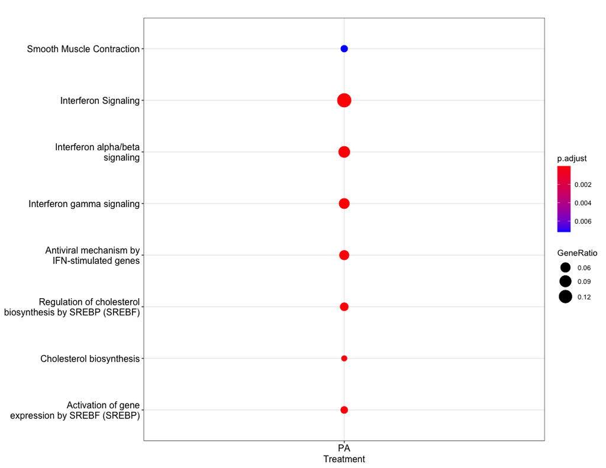

```r
compareRE <- compareCluster(Entrez ~ Treatment+Regulation, data = astro_enrich, fun ="enrichPathway",
                           organism = "human", pAdjustMethod = 'BH', pvalueCutoff = 0.01, qvalueCutoff  = 0.05)

p4 <- dotplot(compareRE, x="Treatment", showCategory = 7) +
  aes(x=fct_relevel(Treatment, c('PA'))) + xlab(NULL) +
  facet_grid(~factor(Regulation, levels = c("Up", "Down")), scale = "free", space = "free") +
  scale_color_gradientn(colours=c("#f7ca64", "#46bac2", "#371ea3"),
  guide=guide_colorbar(reverse=TRUE, order=1)) +
  force_panelsizes(cols = c(0.01, 0.01)) +
  guides(size = guide_legend(override.aes=list(shape=1))) +
  theme(panel.grid.major.y = element_line(linetype='dotted', color='#808080'),
  axis.text.y = element_text(size = 18), axis.text.x = element_text(size = 28),
  panel.grid.major.x = element_blank()) +
  theme(strip.text.x = element_text(size = 24), strip.text.y = element_text(size = 24),
  legend.title = element_text(size = 26, face = "bold"), legend.text = element_text(size = 22))
```

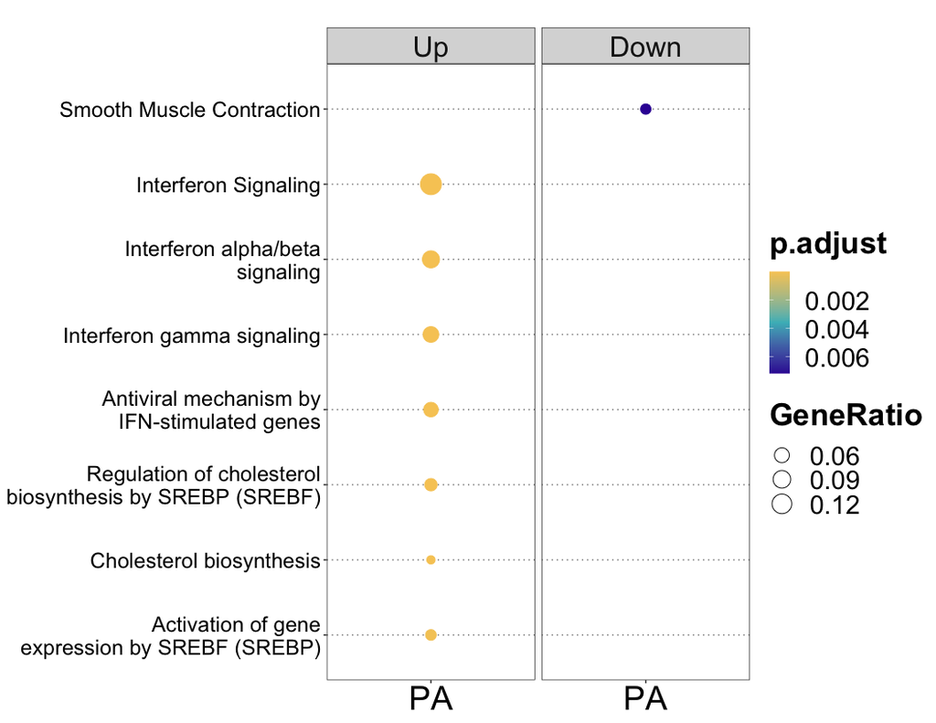

```r
p4
```

```r
ggsave("../Enrichment/enrich_plots/enrichRE.pdf", plot = p4, dpi = 600, width = 9, height = 6)
```

```r
RE_PA <- compareRE@compareClusterResult %>%
  filter( compareRE@compareClusterResult$Treatment == "PA" ) %>%
  arrange( desc(Regulation) )

write.csv(RE_PA, file="../Enrichment/enrich_RE/RE_PA.csv", quote = F, row.names = F)
```

# GoChord

## Palmitic Acid

```r
#Upregulated
PAup_process <- GO_PA %>%
  dplyr::filter( Regulation == "Up") %>%
  dplyr::select( ONTOLOGY, ID, Description, geneID, p.adjust ) %>%
  dplyr::rename( category = ONTOLOGY ) %>%
  dplyr::rename( term = Description ) %>%
  dplyr::rename( genes = geneID ) %>%
  dplyr::rename( adj_pval = p.adjust ) %>%
  dplyr::mutate( genes = str_replace_all(genes, '/', ',') ) %>%
  dplyr::slice(1:8) %>%
  data.frame( . )

PAup_genes <- data.frame(ID=PA_up$PAvsVH_symbol, logFC=PA_up$PAvsVH_logFC, logFC2=PA_up$TiPAvsVH_logFC)

PAup_circ <- circle_dat(PAup_process, PAup_genes)

#Downregulated
PAdown_process <- GO_PA %>%
  dplyr::filter( Regulation == "Down") %>%
  dplyr::select( ONTOLOGY, ID, Description, geneID, p.adjust ) %>%
  dplyr::rename( category = ONTOLOGY ) %>%
  dplyr::rename( term = Description ) %>%
  dplyr::rename( genes = geneID ) %>%
  dplyr::rename( adj_pval = p.adjust ) %>%
  dplyr::mutate( genes = str_replace_all(genes, '/', ',') ) %>%
  dplyr::slice(1:8) %>%
  data.frame( . )

PAdown_genes <- data.frame(ID=PA_down$PAvsVH_symbol, logFC=PA_down$PAvsVH_logFC, logFC2=PA_down$TiPAvsVH_logFC)

PAdown_circ <- circle_dat(PAdown_process, PAdown_genes)
```

```r
PAup_data <- chord_dat(data = PAup_circ, genes = PAup_genes)
PAdown_data <- chord_dat(data = PAdown_circ, genes = PAdown_genes)
head(PAdown_data)
```

```
      actin filament organization regulation of actin filament-based process
LMOD1                           1                                          1
ALPK2                           0                                          0
CSRP1                           0                                          0
CNN1                            0                                          0
ACTC1                           1                                          0
BMP4                            0                                          0
      positive regulation of cytoskeleton organization positive regulation of supramolecular fiber organization
LMOD1                                                1                                                        1
ALPK2                                                0                                                        0
CSRP1                                                0                                                        0
CNN1                                                 0                                                        0
ACTC1                                                0                                                        0
BMP4                                                 0                                                        0
      regulation of actin cytoskeleton organization myofibril assembly actomyosin structure organization
LMOD1                                             1                  1                                 1
ALPK2                                             0                  0                                 0
CSRP1                                             0                  1                                 1
CNN1                                              0                  0                                 1
ACTC1                                             0                  1                                 1
BMP4                                              0                  0                                 0
      muscle cell differentiation     logFC
LMOD1                           1 -2.515748
ALPK2                           1 -1.317497
CSRP1                           1 -1.113402
CNN1                            0 -1.169540
ACTC1                           1 -2.060394
BMP4                            1 -1.493856
```